# Data Show - Medical Appointment No Shows

## Recep Durdu

##### 24.10.2017

No shows are very important for the service sector especially if this service is about health. This data show contains medical appointment record in Brasil including no show information.

What I am trying to achieve is to predict if a person will show up or not.Also try to exhibit statistical information about medical no shows.

Let’s install necesserry packages and load the data.

#### Reading Data

```r
mydata<-read.csv("KaggleV2-May-2016.csv",header=TRUE, stringsAsFactors = FALSE)

names(mydata)
```

```
##  [1] "PatientId"      "AppointmentID"  "Gender"         "ScheduledDay"
##  [5] "AppointmentDay" "Age"            "Neighbourhood"  "Scholarship"
##  [9] "Hipertension"   "Diabetes"       "Alcoholism"     "Handcap"
## [13] "SMS_received"   "No.show"
```

1. PatientId = ID of the patient
2. AppointmentID = ID of the appointment
3. Gender = Gender of patient
4. ScheduledDay = The day which appintment scheduled
5. AppointmentDay = The day which appintment planned to occur
6. Age = Age of the patient
7. Neighbourhood = The place where hospital located
8. Scholarship = If the patient has scholarship or not
9. Hipertension = If the patient has Hipertension or not
10. Diabetes = If the patient has Diabetes or not
11. Alcoholism = If the patient has Alcoholism or not
12. Handcap = If the patient has Handcap or not
13. SMS_received = If the patient received an SMS for the appointment
14. No.show = no show information. “Yes” means patient did not come to the appointment, “No” means patient came to appointment.

Sample of the dataset is like below:

```r
library(knitr)
kable(mydata[1:5, ], caption = "Medical No Shows Sample")
```

Medical No Shows Sample

| PatientId | AppointmentID | Gender | ScheduledDay | AppointmentDay | Age | Neighbourhood | Scholarship | Hipertension | Diabetes | Alcoholism | Handcap | SMS_received | No.show |
| --- | --- | --- | --- | --- | --- | --- | --- | --- | --- | --- | --- | --- | --- |
| 2.987250e+13 | 5642903 | F | 2016-04-29T18:38:08Z | 2016-04-29T00:00:00Z | 62 | JARDIM DA PENHA | 0 | 1 | 0 | 0 | 0 | 0 | No |
| 5.589978e+14 | 5642503 | M | 2016-04-29T16:08:27Z | 2016-04-29T00:00:00Z | 56 | JARDIM DA PENHA | 0 | 0 | 0 | 0 | 0 | 0 | No |
| 4.262962e+12 | 5642549 | F | 2016-04-29T16:19:04Z | 2016-04-29T00:00:00Z | 62 | MATA DA PRAIA | 0 | 0 | 0 | 0 | 0 | 0 | No |
| 8.679512e+11 | 5642828 | F | 2016-04-29T17:29:31Z | 2016-04-29T00:00:00Z | 8 | PONTAL DE CAMBURI | 0 | 0 | 0 | 0 | 0 | 0 | No |
| 8.841186e+12 | 5642494 | F | 2016-04-29T16:07:23Z | 2016-04-29T00:00:00Z | 56 | JARDIM DA PENHA | 0 | 1 | 1 | 0 | 0 | 0 | No |

### Structure of the Data

```r
str(mydata)
```

```
## 'data.frame':    110527 obs. of  14 variables:
##  $ PatientId     : num  2.99e+13 5.59e+14 4.26e+12 8.68e+11 8.84e+12 ...
##  $ AppointmentID : int  5642903 5642503 5642549 5642828 5642494 5626772 5630279 5630575 5638447 5629123 ...
##  $ Gender        : chr  "F" "M" "F" "F" ...
##  $ ScheduledDay  : chr  "2016-04-29T18:38:08Z" "2016-04-29T16:08:27Z" "2016-04-29T16:19:04Z" "2016-04-29T17:29:31Z" ...
##  $ AppointmentDay: chr  "2016-04-29T00:00:00Z" "2016-04-29T00:00:00Z" "2016-04-29T00:00:00Z" "2016-04-29T00:00:00Z" ...
##  $ Age           : int  62 56 62 8 56 76 23 39 21 19 ...
##  $ Neighbourhood : chr  "JARDIM DA PENHA" "JARDIM DA PENHA" "MATA DA PRAIA" "PONTAL DE CAMBURI" ...
##  $ Scholarship   : int  0 0 0 0 0 0 0 0 0 0 ...
##  $ Hipertension  : int  1 0 0 0 1 1 0 0 0 0 ...
##  $ Diabetes      : int  0 0 0 0 1 0 0 0 0 0 ...
##  $ Alcoholism    : int  0 0 0 0 0 0 0 0 0 0 ...
##  $ Handcap       : int  0 0 0 0 0 0 0 0 0 0 ...
##  $ SMS_received  : int  0 0 0 0 0 0 0 0 0 0 ...
##  $ No.show       : chr  "No" "No" "No" "No" ...
```

We need to work on data structures of variables in order to make some light exploration on the data.For example we can change integers to logical variables sucj-h as scholarship, diabetes etc. because these variables are shown as 1 or 0 in the dataset.

```r
mydata$PatientId <- as.character((mydata$PatientId))
mydata$ScheduledDay<-as.Date(mydata$ScheduledDay)
mydata$AppointmentDay<-as.Date(mydata$AppointmentDay)
mydata$Handcap<- as.logical(mydata$Handcap)
mydata$Scholarship<- as.logical(mydata$Scholarship)
mydata$Hipertension<- as.logical(mydata$Hipertension)
mydata$Diabetes<- as.logical(mydata$Diabetes)
mydata$Alcoholism<- as.logical(mydata$Alcoholism)
mydata$SMS_received<- as.logical(mydata$SMS_received)
str(mydata)
```

```
## 'data.frame':    110527 obs. of  14 variables:
##  $ PatientId     : chr  "29872499824296" "558997776694438" "4262962299951" "867951213174" ...
##  $ AppointmentID : int  5642903 5642503 5642549 5642828 5642494 5626772 5630279 5630575 5638447 5629123 ...
##  $ Gender        : chr  "F" "M" "F" "F" ...
##  $ ScheduledDay  : Date, format: "2016-04-29" "2016-04-29" ...
##  $ AppointmentDay: Date, format: "2016-04-29" "2016-04-29" ...
##  $ Age           : int  62 56 62 8 56 76 23 39 21 19 ...
##  $ Neighbourhood : chr  "JARDIM DA PENHA" "JARDIM DA PENHA" "MATA DA PRAIA" "PONTAL DE CAMBURI" ...
##  $ Scholarship   : logi  FALSE FALSE FALSE FALSE FALSE FALSE ...
##  $ Hipertension  : logi  TRUE FALSE FALSE FALSE TRUE TRUE ...
##  $ Diabetes      : logi  FALSE FALSE FALSE FALSE TRUE FALSE ...
##  $ Alcoholism    : logi  FALSE FALSE FALSE FALSE FALSE FALSE ...
##  $ Handcap       : logi  FALSE FALSE FALSE FALSE FALSE FALSE ...
##  $ SMS_received  : logi  FALSE FALSE FALSE FALSE FALSE FALSE ...
##  $ No.show       : chr  "No" "No" "No" "No" ...
```

In order to see the number of no shows(no show column get “YEs” value if a patient did not come to appointment :

```r
check<- table(mydata$No.show)
check
```

```
##
##    No   Yes
## 88208 22319
```

Check the percentage of the patients that did not come to appointment:

```r
options(repos="https://cran.rstudio.com" )
install.packages("formattable")
library(formattable)
ratio<-(check["Yes"]/(check["Yes"]+check["No"]))
percent(ratio,1)
```

```
##   Yes
## 20.2%
```

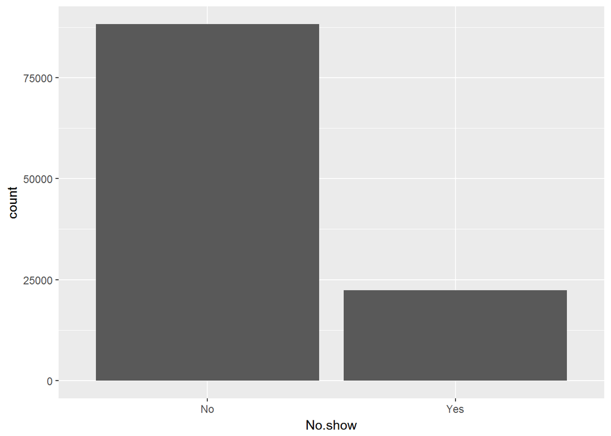

```r
library(ggplot2)
ggplot(mydata, aes(x=No.show )) + geom_bar()
```

If we look at the genders and appointment status, we can see that there is no significant difference between males and females.

```r
check2<- table(mydata$No.show, mydata$Gender)
check2
```

```
##
##           F     M
##   No  57246 30962
##   Yes 14594  7725
```

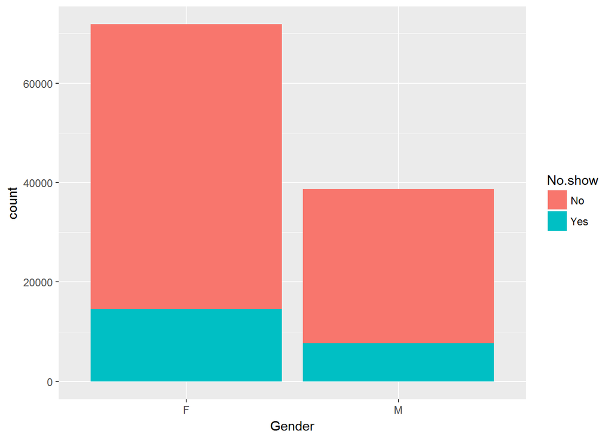

```r
ggplot(mydata, aes(x=Gender, fill=No.show )) + geom_bar()
```

We can evaluate if sending reminder SMS to the patients changes the no show ratio.

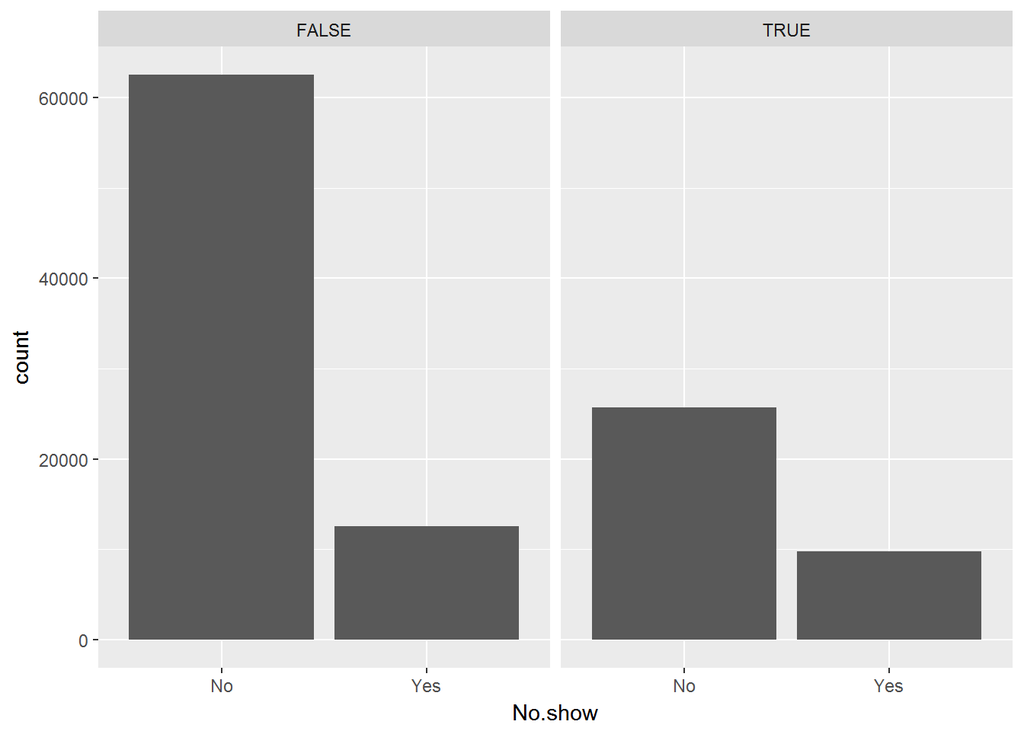

```r
ggplot(mydata, aes(x=No.show )) + geom_bar() + facet_grid(.~SMS_received)
```